# Diversity, integration, and variability of intergenerational relationships in old age: new insights from personal network research

Reproducible project

Raffaele Vacca http://www.raffaelevacca.com/ (Department of Social and Political Sciences, University of Milan)  
2024-02-20

**Reproducible project for:**

Vacca, R., & Bianchi, F. (2024). [Diversity, integration, and variability of intergenerational relationships in old age: New insights from personal network research](https://doi.org/10.1016/j.ssresearch.2024.102991). Social Science Research, 119, 102991.

([GitHub repository](https://github.com/raffaelevacca/Vacca_Bianchi_2024_SSR))

# Table 1

| var | value | range |
| --- | --- | --- |
| Count: All | 12 (6.6) | 0-29 |
| Count: Family | 7.2 (4.8) | 0-26 |
| Count: Active | 7.5 (4.6) | 0-23 |
| Count: IG | 4.9 (3.6) | 0-17 |
| Count: IG active | 3 (2.8) | 0-14 |
| Count: Adult children | 2.8 (2.1) | 0-10 |
| _ |  |  |
| Prop: IG | 0.42 (0.26) | 0-1 |
| Prop: IG active | 0.42 (0.31) | 0-1 |
| Prop: Adult children | 0.26 (0.22) | 0-1 |
| _ |  |  |
| Max proportion network known (p) | 0.61 (0.27) | 0-1 |
| Max relative degree (d) | 0.82 (0.25) | 0-1 |
| Max relative betweenness (b) | 0.38 (0.46) | 0-1 |
| _ |  |  |
| Ego has IG ties | 202 (87.8) |  |
| Ego has IG active ties | 183 (79.6) |  |
| Ego has adult children in network | 177 (77.3) |  |
| IG alter knows all network members | 42 (18.5) |  |
| IG alter has highest degree | 114 (50.4) |  |
| IG alter has highest betweenness | 42 (28) |  |

# Table 2

| Variable | Category | IG ties | Same-generation ties | All ties | pval |
| --- | --- | --- | --- | --- | --- |
| N (row %) |  | 1115 (41) | 1632 (59) | 2747 (100) |  |
| _ |  |  |  |  |  |
| _ |  |  |  |  |  |
| Alter gender | Male | 533 (48) | 716 (44) | 1249 (45) | 0.0500000 |
| Alter gender | Female | 582 (52) | 916 (56) | 1498 (55) | 0.0500000 |
| _ |  |  |  |  |  |
| Alter role | imm.fam | 640 (57) | 329 (20) | 969 (36) | 0.0000000 |
| Alter role | ext.fam | 475 (43) | 203 (13) | 678 (25) | 0.0000000 |
| Alter role | other | 0 (0) | 1081 (67) | 1081 (40) | 0.0000000 |
| _ |  |  |  |  |  |
| Frequency of contact | daily | 197 (18) | 396 (24) | 593 (22) | 0.0000000 |
| Frequency of contact | weekly | 502 (45) | 626 (38) | 1128 (41) | 0.0000000 |
| Frequency of contact | monthly | 307 (28) | 418 (26) | 725 (26) | 0.0000000 |
| Frequency of contact | yearly | 109 (10) | 192 (12) | 301 (11) | 0.0000000 |
| _ |  |  |  |  |  |
| Coresident | No | 1090 (98) | 1507 (92) | 2597 (95) | 0.0000000 |
| Coresident | Yes | 25 (2) | 125 (8) | 150 (5) | 0.0000000 |
| _ |  |  |  |  |  |
| _ |  |  |  |  |  |
| Proportion network known (p) |  | 0.57 (0.25) | 0.34 (0.27) | 0.44 (0.28) | 0.0000000 |
| Relative degree (d) |  | 0.74 (0.26) | 0.52 (0.34) | 0.61 (0.33) | 0.0000000 |
| Relative betweenness (b) |  | 0.13 (0.31) | 0.13 (0.31) | 0.13 (0.31) | 0.6410377 |
| Top 5 alter roles |  | oth.fam, child, child.in.law | friend, rel.vol, sibling, neighbor, sib.in.law | oth.fam, friend, child, rel.vol, child.in.law |  |

# Figure 1

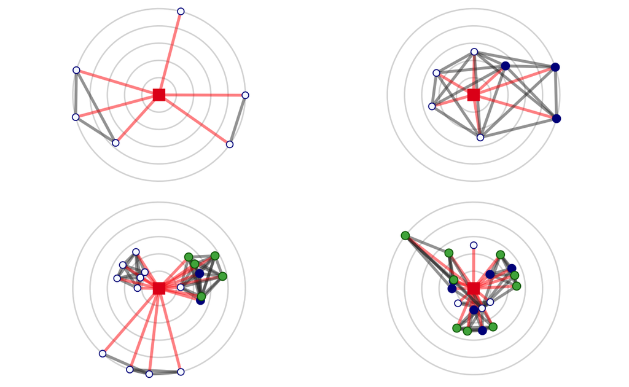

# Figure 2

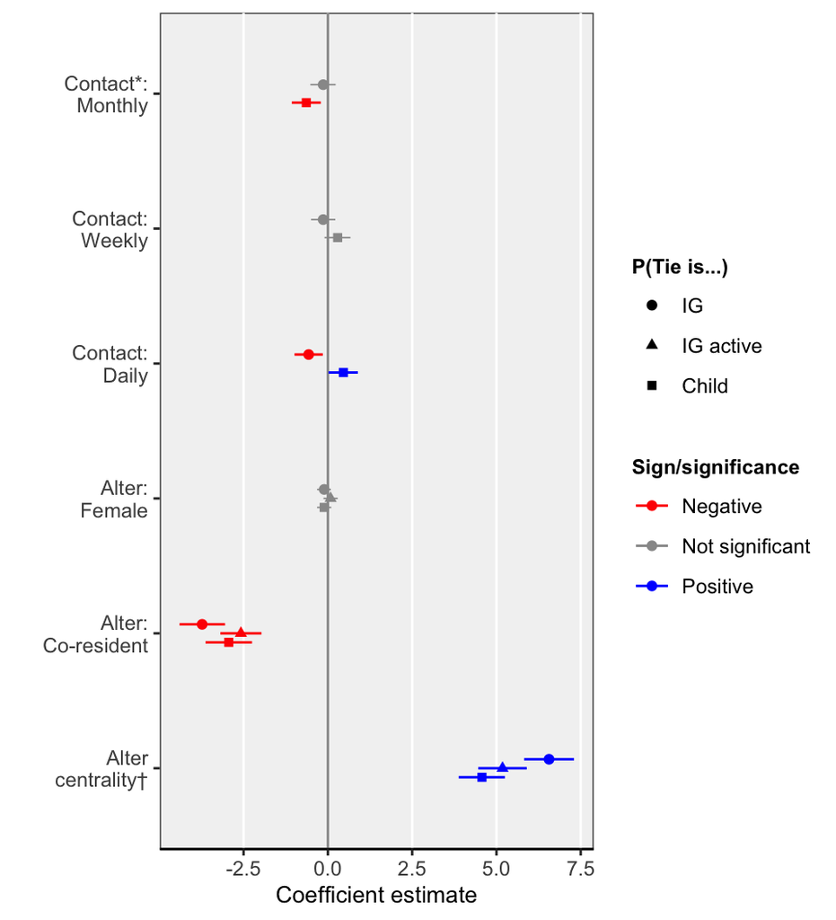

# Figure 3

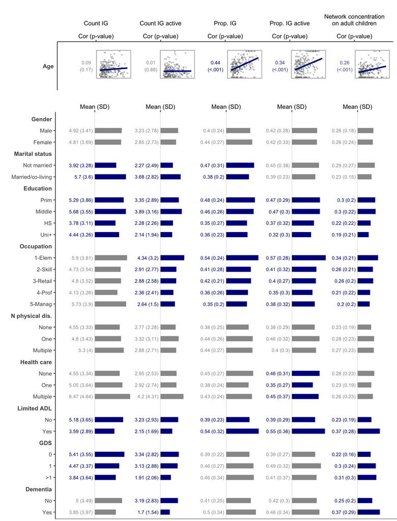

# Figure 4

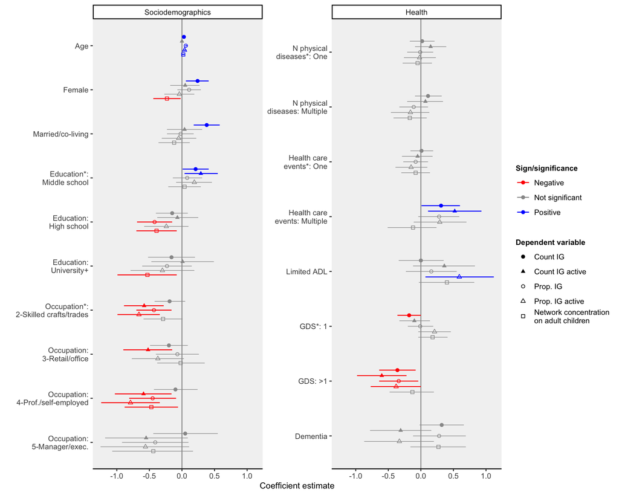

# Table S1

Done manually (no code).

# Table S2

variable

cat

Mean (sd) or N (%)

Age

82.98 (5.83)

Gender

Female

129 (56.1)

Marital status

Married/co-living

122 (53)

_

Education level

Primary school

77 (33.5)

Education level

Middle school

57 (24.8)

Education level

High school

60 (26.1)

Education level

University or higher

36 (15.7)

_

Occupation type

1. Elementary/menial

41 (17.8)

Occupation type

2. Skilled crafts/trades

85 (37)

Occupation type

3. Retail/office employee

40 (17.4)

Occupation type

4. Professional/self-employed

53 (23)

Occupation type

5. Manager/executive

11 (4.8)

_

N physical diseases

None

74 (32.2)

N physical diseases

One

92 (40)

N physical diseases

Multiple

64 (27.8)

_

Health care events

None

129 (56.1)

Health care events

One

86 (37.4)

Health care events

Multiple

15 (6.5)

Limited ADL

Yes

46 (20)

_

GDS score

0

125 (54.3)

GDS score

1

62 (27)

GDS score

>1

43 (18.7)

Has dementia diagnosis

Yes

27 (11.7)

Lives in ALF

Yes

36 (15.7)

# Table S3

label

Count IG ties: Est. (SE)

Count IG ties: P-value

Count IG active ties: Est. (SE)

Count IG active ties: P-value

Sociodemographics

Age

0.03 (0.01)

0***

0 (0.01)

0.88

Female

0.24 (0.09)

0.01**

0.05 (0.12)

0.69

Marital status (ref: Single/widow)

Married/co-living

0.38 (0.1)

0***

0.04 (0.14)

0.79

Education level (ref: Primary)

Middle school

0.21 (0.1)

0.04*

0.29 (0.13)

0.03*

High school

-0.15 (0.12)

0.22

-0.07 (0.16)

0.68

University or more

-0.16 (0.18)

0.38

0.01 (0.24)

0.98

Occupational status (ref: 1. Elementary/menial)

2. Skilled crafts/trades

-0.19 (0.12)

0.11

-0.58 (0.16)

0***

3. Retail/office employee

-0.2 (0.15)

0.17

-0.52 (0.19)

0.01**

4. Professional/self-employed

-0.1 (0.17)

0.57

-0.59 (0.22)

0.01**

5. Manager/executive

0.05 (0.25)

0.83

-0.55 (0.32)

0.09

Health

N physical diseases (ref: None)

One

0.02 (0.1)

0.83

0.15 (0.12)

0.23

Multiple

0.11 (0.1)

0.29

0.07 (0.14)

0.63

Recent health care events (ref: None)

One

0.01 (0.09)

0.89

-0.05 (0.12)

0.66

Multiple

0.31 (0.15)

0.04*

0.52 (0.21)

0.01*

Limited ADL

0 (0.18)

0.98

0.36 (0.24)

0.14

GDS (ref: 0)

1

-0.18 (0.09)

0.05

-0.1 (0.12)

0.42

>1

-0.36 (0.15)

0.01*

-0.6 (0.19)

0**

Dementia

0.32 (0.17)

0.06

-0.31 (0.24)

0.19

Other

In ALF

-0.77 (0.2)

0***

-0.73 (0.26)

0.01**

Phone interview

-0.02 (0.11)

0.82

0.23 (0.14)

0.1

(Intercept)

-1.24 (0.71)

0.08

1.43 (0.93)

0.13

Log theta

2.53 (0.36)

0***

1.84 (0.31)

0***

Model statistics

LogLik

-543.62

-461.26

AIC

1139.25

974.52

N obs

230

230

# Table S4

label

Proportion IG ties: Est. (SE)

Proportion IG ties: P-value

Proportion IG active ties: Est. (SE)

Proportion IG active ties: P-value

Concentration children: Est. (SE)

Concentration children: P-value

Sociodemographics

Age

0.06 (0.01)

0***

0.04 (0.01)

0***

0.02 (0.01)

0.03*

Female

0.11 (0.09)

0.23

-0.04 (0.12)

0.74

-0.23 (0.11)

0.03*

Marital status (ref: Single/widow)

Married/co-living

-0.02 (0.11)

0.83

-0.05 (0.14)

0.72

-0.12 (0.12)

0.32

Education level (ref: Primary)

Middle school

0.08 (0.12)

0.48

0.19 (0.14)

0.18

0.04 (0.13)

0.77

High school

-0.42 (0.14)

0**

-0.24 (0.17)

0.16

-0.39 (0.16)

0.01*

University or more

-0.23 (0.19)

0.23

-0.3 (0.25)

0.23

-0.53 (0.23)

0.02*

Occupational status (ref: 1. Elementary/menial)

2. Skilled crafts/trades

-0.43 (0.14)

0**

-0.66 (0.16)

0***

-0.29 (0.15)

0.06

3. Retail/office employee

-0.07 (0.17)

0.69

-0.37 (0.2)

0.07

-0.02 (0.18)

0.94

4. Professional/self-employed

-0.45 (0.18)

0.02*

-0.79 (0.23)

0***

-0.47 (0.21)

0.02*

5. Manager/executive

-0.41 (0.26)

0.11

-0.56 (0.34)

0.1

-0.44 (0.31)

0.16

Health

N physical diseases (ref: None)

One

-0.01 (0.1)

0.93

-0.02 (0.13)

0.9

-0.05 (0.12)

0.64

Multiple

-0.11 (0.11)

0.35

-0.16 (0.15)

0.27

-0.17 (0.13)

0.2

Recent health care events (ref: None)

One

-0.08 (0.1)

0.4

-0.15 (0.12)

0.24

-0.08 (0.11)

0.47

Multiple

0.28 (0.16)

0.09

0.29 (0.21)

0.16

-0.12 (0.19)

0.52

Limited ADL

0.16 (0.2)

0.41

0.59 (0.27)

0.03*

0.4 (0.22)

0.07

GDS (ref: 0)

1

-0.01 (0.1)

0.96

0.21 (0.13)

0.1

0.18 (0.11)

0.11

>1

-0.34 (0.15)

0.03*

-0.38 (0.2)

0.05

-0.13 (0.17)

0.44

Dementia

0.28 (0.21)

0.17

-0.33 (0.27)

0.22

0.27 (0.22)

0.22

Other

In ALF

-0.07 (0.24)

0.77

-0.18 (0.31)

0.56

0 (0.26)

0.99

Phone interview

-0.21 (0.11)

0.06

0 (0.14)

0.98

-0.09 (0.13)

0.47

(Intercept)

-5.12 (0.77)

0***

-3.38 (0.98)

0***

-2.36 (0.86)

0.01**

Model statistics

Deviance

507.23

512.26

423.63

AIC

1080

940.42

926.79

N obs

227

224

227

# Table S5

label

Pr(Tie is IG): Est. (SE)

Pr(Tie is IG): P-value

Pr(Tie is IG active): Est. (SE)

Pr(Tie is IG active): P-value

Pr(Tie is child): Est. (SE)

Pr(Tie is child): P-value

Ego characteristics

Age

0.59 (0.12)

0***

0.28 (0.12)

0.02*

0.17 (0.1)

0.09

Female

0.13 (0.22)

0.55

0 (0.22)

0.99

-0.29 (0.19)

0.12

Marital status (ref: Single/widow)

Married/co-living

0.25 (0.24)

0.31

0.41 (0.25)

0.1

0.15 (0.21)

0.47

Education level (ref: Primary)

Middle school

0.79 (0.27)

0**

0.57 (0.27)

0.03*

0.44 (0.22)

0.05*

High school

-0.15 (0.31)

0.62

-0.06 (0.31)

0.84

-0.29 (0.26)

0.27

University or more

0.17 (0.44)

0.7

-0.22 (0.46)

0.63

-0.44 (0.39)

0.26

Occupational status (ref: 1. Elementary/menial)

2. Skilled crafts/trades

-0.01 (0.32)

0.97

-0.53 (0.31)

0.09

0.26 (0.26)

0.32

3. Retail/office employee

-0.28 (0.39)

0.47

-0.78 (0.38)

0.04*

0.01 (0.32)

0.98

4. Professional/self-employed

-0.15 (0.42)

0.73

-0.64 (0.42)

0.13

-0.04 (0.36)

0.92

5. Manager/executive

-0.36 (0.61)

0.55

-0.55 (0.62)

0.38

0.12 (0.53)

0.83

Health

N physical diseases (ref: None)

One

0.24 (0.23)

0.31

0.39 (0.24)

0.1

0.04 (0.2)

0.83

Multiple

0.14 (0.27)

0.6

0.12 (0.27)

0.67

0.03 (0.23)

0.91

Recent health care events (ref: None)

One

-0.14 (0.23)

0.52

-0.37 (0.23)

0.1

-0.16 (0.19)

0.41

Multiple

0.87 (0.4)

0.03*

0.56 (0.41)

0.17

0.35 (0.34)

0.3

Limited ADL

0.5 (0.48)

0.3

0.83 (0.47)

0.07

0.63 (0.38)

0.1

GDS (ref: 0)

1

-0.52 (0.24)

0.03*

-0.26 (0.24)

0.27

-0.16 (0.2)

0.43

>1

-0.32 (0.33)

0.34

-0.66 (0.34)

0.05

-0.03 (0.29)

0.92

Dementia

-0.45 (0.46)

0.33

-1.08 (0.45)

0.02*

-0.11 (0.37)

0.77

Tie/alter characteristics

Contact frequency (ref: Yearly)

Monthly

-0.14 (0.19)

0.45

-0.64 (0.22)

0**

Weekly

-0.14 (0.18)

0.44

0.29 (0.2)

0.15

Daily

-0.57 (0.21)

0.01**

0.46 (0.22)

0.04*

Alter is female

-0.11 (0.1)

0.26

0.08 (0.11)

0.46

-0.11 (0.11)

0.32

Alter is co-resident

-3.73 (0.35)

0***

-2.58 (0.31)

0***

-2.94 (0.35)

0***

Alter centrality

6.56 (0.38)

0***

5.18 (0.37)

0***

4.57 (0.35)

0***

Other

Ego in ALF

-1.98 (0.54)

0***

-1.42 (0.51)

0.01**

-1.43 (0.44)

0**

Phone interview

0.04 (0.28)

0.88

0.27 (0.28)

0.34

0.2 (0.23)

0.39

(Intercept)

-3.1 (0.46)

0***

-3.43 (0.46)

0***

-3.4 (0.43)

0***

Variance components

Ego-level SD

1.12

1.09

0.82

Model statistics

Deviance

2426.35

2180.22

2218.07

AIC

2874.31

2591.53

2544.33

N obs (ties)

2747

2747

2747

N obs (egos)

227

227

227

# Table S6

| var | value | range |
| --- | --- | --- |
| Count: All | 12.5 (6.7) | 0-29 |
| Count: Family | 7.2 (4.7) | 0-26 |
| Count: Active | 7.4 (4.5) | 0-23 |
| Count: IG | 4.8 (3.6) | 0-17 |
| Count: IG active | 2.9 (2.9) | 0-14 |
| Count: Adult children | 2.5 (2.1) | 0-10 |
| _ |  |  |
| Prop: IG | 0.39 (0.25) | 0-1 |
| Prop: IG active | 0.4 (0.31) | 0-1 |
| Prop: Adult children | 0.23 (0.21) | 0-1 |
| _ |  |  |
| Max proportion network known (p) | 0.6 (0.26) | 0-1 |
| Max relative degree (d) | 0.86 (0.21) | 0.19-1 |
| Max relative betweenness (b) | 0.46 (0.48) | 0-1 |
| _ |  |  |
| Ego has IG ties | 92 (86) |  |
| Ego has IG active ties | 81 (75.7) |  |
| Ego has adult children in network | 75 (70.8) |  |
| IG alter knows all network members | 16 (15.2) |  |
| IG alter has highest degree | 55 (52.9) |  |
| IG alter has highest betweenness | 25 (32.9) |  |

# Table S7

| Variable | Category | IG ties | Same-generation ties | All ties | pval |
| --- | --- | --- | --- | --- | --- |
| N (row %) |  | 511 (39) | 810 (61) | 1321 (100) |  |
| _ |  |  |  |  |  |
| _ |  |  |  |  |  |
| Alter gender | Male | 234 (46) | 348 (43) | 582 (44) | 0.3400000 |
| Alter gender | Female | 277 (54) | 462 (57) | 739 (56) | 0.3400000 |
| _ |  |  |  |  |  |
| Alter role | imm.fam | 268 (52) | 141 (17) | 409 (31) | 0.0000000 |
| Alter role | ext.fam | 243 (48) | 112 (14) | 355 (27) | 0.0000000 |
| Alter role | other | 0 (0) | 554 (69) | 554 (42) | 0.0000000 |
| _ |  |  |  |  |  |
| Frequency of contact | daily | 99 (19) | 200 (25) | 299 (23) | 0.0100000 |
| Frequency of contact | weekly | 216 (42) | 277 (34) | 493 (37) | 0.0100000 |
| Frequency of contact | monthly | 149 (29) | 236 (29) | 385 (29) | 0.0100000 |
| Frequency of contact | yearly | 47 (9) | 97 (12) | 144 (11) | 0.0100000 |
| _ |  |  |  |  |  |
| Coresident | No | 493 (96) | 747 (92) | 1240 (94) | 0.0000000 |
| Coresident | Yes | 18 (4) | 63 (8) | 81 (6) | 0.0000000 |
| _ |  |  |  |  |  |
| _ |  |  |  |  |  |
| Proportion network known (p) |  | 0.56 (0.24) | 0.34 (0.26) | 0.43 (0.27) | 0.0000000 |
| Relative degree (d) |  | 0.78 (0.24) | 0.52 (0.34) | 0.62 (0.33) | 0.0000000 |
| Relative betweenness (b) |  | 0.17 (0.35) | 0.13 (0.32) | 0.15 (0.33) | 0.1531272 |
| Top 5 alter roles |  | oth.fam, child, child.in.law | friend, rel.vol, neighbor, sibling, work | oth.fam, friend, child, rel.vol, child.in.law |  |

# Figure S1

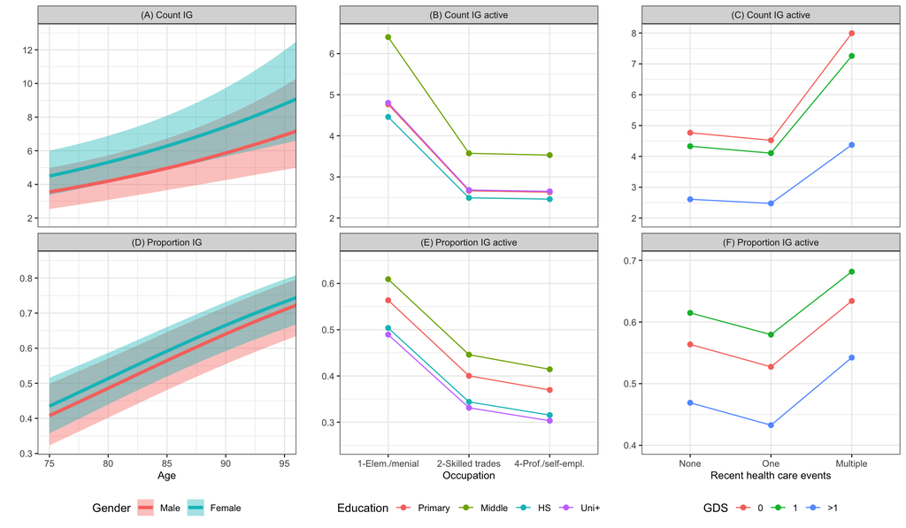

# Figure S2

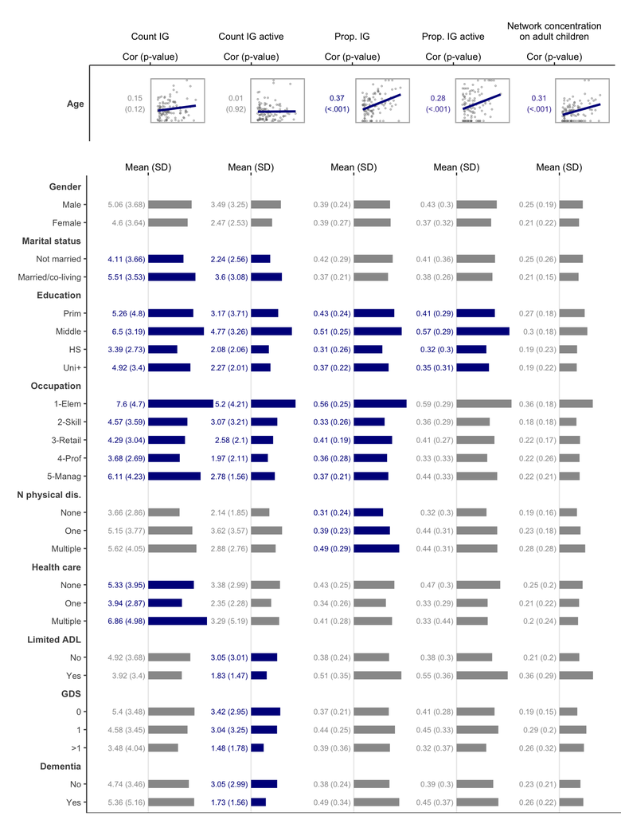

# Figure S3

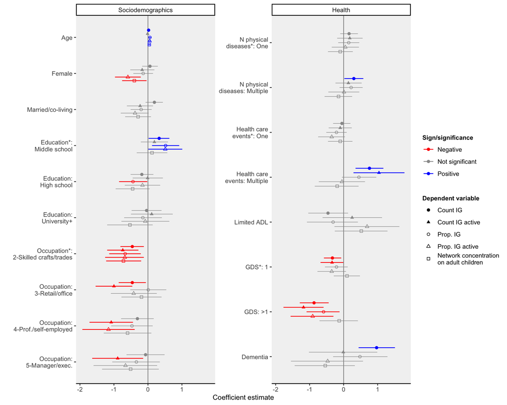